# bike_project slides

## This data set includes information about individual rides made in a bike-sharing system covering the greater San Francisco Bay area.

### When are most trips taken in terms of time of day, day of the week, or month of the year?

### How long does the average trip take?

### Does the above depend on if a user is a subscriber or customer?

## Investigation Overview

##### i am interested in finding what affect the durtion of bike sharing

## features you need to focus on to support your investigation

###### I expect that user gender will have the strongest effect on duration

###### I also think that user type and days of week alos at any time per day may affect the duration

# average and distrbution of duration

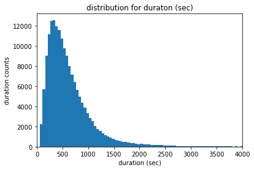

```python
# show distribution for duraton
duration_bins=np.arange(bike['duration_sec'].min(), bike['duration_sec'].max()+50,50)
plt.hist(data=bike , x='duration_sec', bins=duration_bins);
plt.xlim(0,4000);
plt.xlabel('duration (sec)');
plt.title('distribution for duraton (sec)');
plt.ylabel('duration counts');
```

## Waht is the average of the duration distribution?

### plot distrbution of duration per each 3 hours intervals per a day

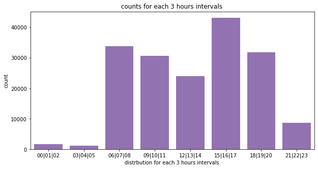

```python
#plot distrbution of duration per each 3 hours intervals per a day
plt.figure(figsize=[10,5])
sb.countplot(data=bike , x='day_hours', color =base_color );
plt.title('counts for each 3 hours intervals ')
plt.xlabel('distrbution for each 3 hours intervals ');
```

### at which time in aday number of user needs a bike is max ? and is the most user male or female , customer or subscriber ?

##### we can find that the best time the user need a bike is form 6 :11 at morning ,and form 15:20

##### also number of mens are greater then womens also subscriber type is the most user type

### find distrbution of duration per a day for all the month also per hours throght a day

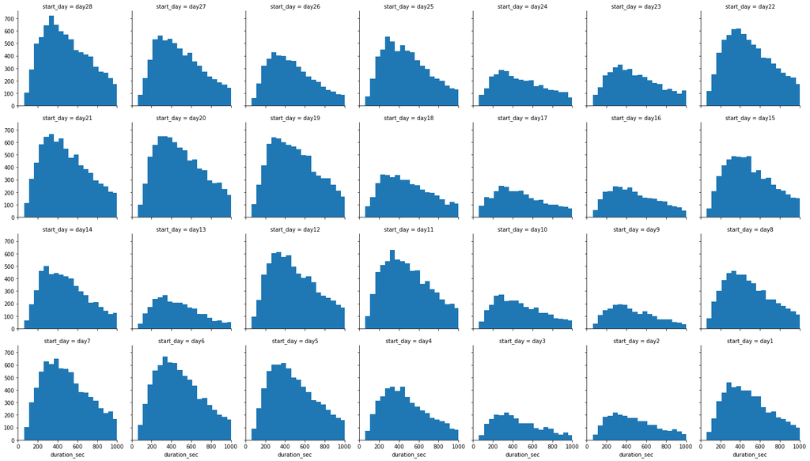

```python
## plot matrix of duration_sec features against days features.
g=sb.FacetGrid(data=bike , col='start_day', col_wrap=7)
g.set(xlim=(0,1000))
g.map(plt.hist , 'duration_sec' , bins=duration_bins);
```

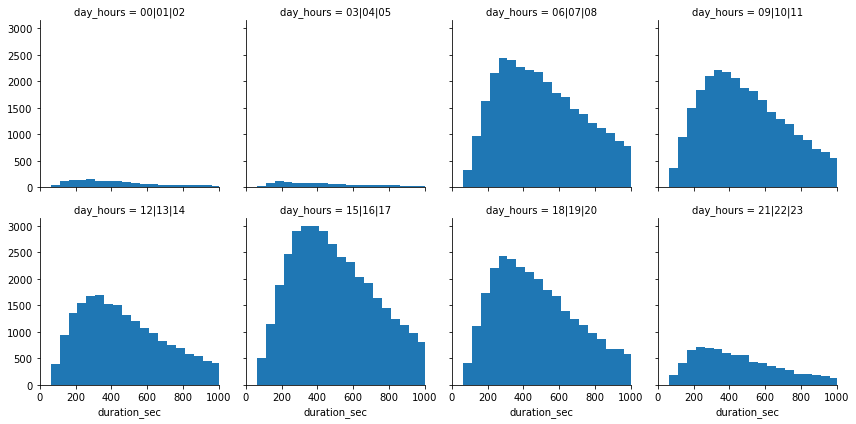

```python
## plot matrix of duration_sec features against horus per day  features.
g=sb.FacetGrid(data=bike , col='day_hours', col_wrap=4)
g.set(xlim=(0,1000))
g.map(plt.hist , 'duration_sec' , bins=duration_bins);
```

### which days in month that have long time for bike sharing , also at which time in aday?

#### the best time per a day is form 15 :17 at mind of the day , almost in 3 days at the end of the week

#### realtion between duration_sec vs [member_gender , user_type, start_day, day_hours ]

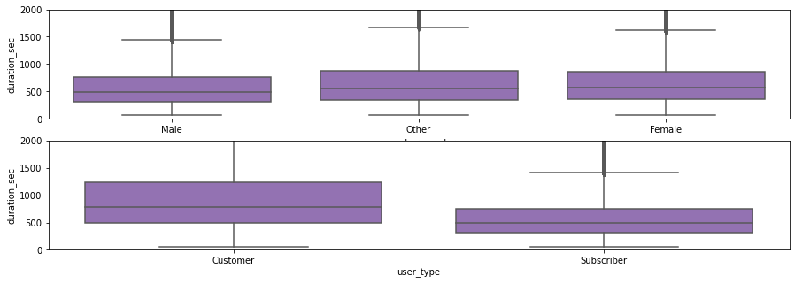

```python
fig,ax=plt.subplots(nrows=2, figsize=[15,5])
for i in range(2):
    var=cat[i]
    sb.boxplot(data=bike , x= var, y= 'duration_sec' ,color =base_color, ax=ax[i])
    ax[i].set_ylim(0,2000)
```

## what is the distrbution of duration for gender and user type feactures ?

### also most of the user is subscriber type

### but the distrbution for duration is less than compare with the duration distrbution for customer type

### the same thing for male duration distrbution is less than female desbite male > female

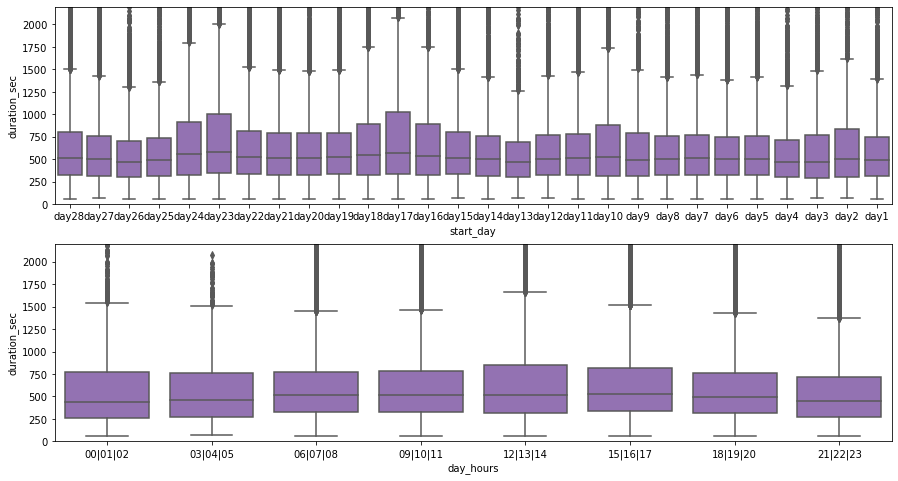

```python
fig,ax=plt.subplots(nrows=2, figsize=[15,8])
for i in range(2,4):
    var=cat[i]
    sb.boxplot(data=bike , x= var, y= 'duration_sec' ,color =base_color, ax=ax[i-2])
    ax[i-2].set_ylim(0,2200)
```

### what is the day has the bigest duration distrbution?what is the time interval per a day has the bigest duration distrbution?

#### days (10-02-2019, 17-02-2019, 18-02-2019, 23-02-2019 ,24-02-2019)

#### intervals form (12 : 14)

##### distrbutions for time intervals per day also distrbution for user typer per gender

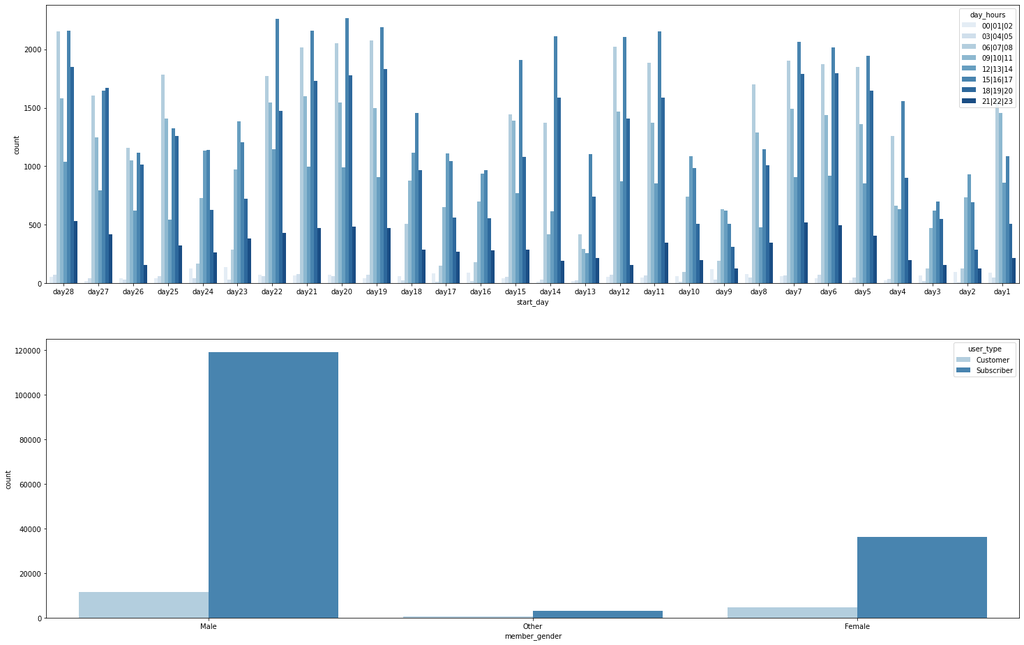

```python
plt.figure(figsize = [25, 25])

# subplot 1: day_hours  vs day
plt.subplot(3, 1, 1)
sb.countplot(data = bike, x = 'start_day', hue = 'day_hours',palette = 'Blues')

# subplot 2: user type   vs gender
plt.subplot(3, 1, 2)
sb.countplot(data = bike, x = 'member_gender', hue = 'user_type', palette = 'Blues');
```

#### almost all males and female are subscriber type also males is greater than females

### plot duration distrbution for ervey day with 3 hours per day

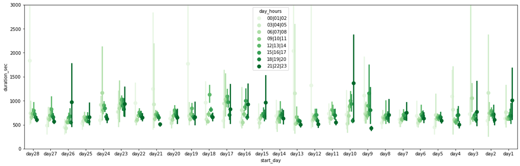

```python
#plot duration distrbution for ervey day per  with each 3 hourd per day
fig = plt.figure(figsize = [20,6])
sb.pointplot(data = bike, x = 'start_day', y = 'duration_sec', hue = 'day_hours',
           palette = 'Greens', linestyles = '', dodge = 0.4)
plt.ylim(0,3000);
```

## what is the relation of duration and numeric features days of months and hours of day?

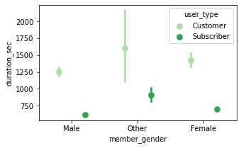

```python
#plot duration distrbution for ervey day per  with each 3 hourd per day
fig = plt.figure(figsize = [5,3])
sb.pointplot(data = bike, x = 'member_gender', hue = 'user_type', y = 'duration_sec',
           palette = 'Greens', linestyles = '', dodge = 0.4);
```

### what is the relation between duration and to categoricals feature of user type and gender ?

### customer has higher values of duration for all type of gender

### when gender is not female or male there is few customer type